# Environ 710 Lab 4: Confidence Intervals

Natalia Neal-Walthall

9.26.18

# Problem 1

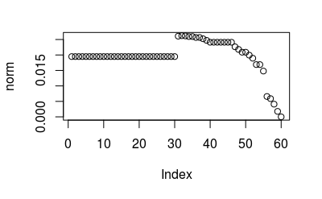

```r
AfrPlots <- read.csv("AfrPlots.csv")
Death <- sort(AfrPlots$Dead)
myqqplot <- function(x) {
perc <- c()
for (i in 1:length(x)){
perc [i] <-(i/(length(x)+.0001))
}
}
md <- mean(Death)
sdd <- sqrt(var(Death))
myqqplot(Death)
norm <- dnorm(Death, mean = md, sd = sdd)
Theoretical_Quantiles <- qnorm(perc/100, mean = 0, sd = 1)
plot(norm)
```

```r
#Sample_Quantiles <- -qnorm(Death, mean = md, sd = sdd )
Theoretical_Quantiles
```

```
 [1] -2.13e+00 -1.83e+00 -1.64e+00 -1.50e+00 -1.38e+00 -1.28e+00 -1.19e+00 -1.11e+00 -1.04e+00
[10] -9.67e-01 -9.03e-01 -8.42e-01 -7.84e-01 -7.28e-01 -6.74e-01 -6.23e-01 -5.73e-01 -5.24e-01
[19] -4.77e-01 -4.31e-01 -3.85e-01 -3.41e-01 -2.97e-01 -2.53e-01 -2.10e-01 -1.68e-01 -1.26e-01
[28] -8.37e-02 -4.18e-02 -2.09e-06  4.18e-02  8.36e-02  1.26e-01  1.68e-01  2.10e-01  2.53e-01
[37]  2.97e-01  3.41e-01  3.85e-01  4.31e-01  4.77e-01  5.24e-01  5.73e-01  6.23e-01  6.74e-01
[46]  7.28e-01  7.83e-01  8.42e-01  9.03e-01  9.67e-01  1.04e+00  1.11e+00  1.19e+00  1.28e+00
[55]  1.38e+00  1.50e+00  1.64e+00  1.83e+00  2.13e+00  4.65e+00
```

```r
Sample_Quantiles
```

```
 [1] Inf Inf Inf Inf Inf Inf Inf Inf Inf Inf Inf Inf Inf Inf Inf Inf Inf Inf Inf Inf Inf Inf
[23] Inf Inf Inf Inf Inf Inf Inf Inf NaN NaN NaN NaN NaN NaN NaN NaN NaN NaN NaN NaN NaN NaN
[45] NaN NaN NaN NaN NaN NaN NaN NaN NaN NaN NaN NaN NaN NaN NaN NaN
```

```r
#plot(Theoretical_Quantiles,Sample_Quantiles, main = "My Q-Q Plot")
abline(lm(Sample_Quantiles ~ Theoretical_Quantiles))
```

[output not shown]

Q Q Plots (Quantile-Quantile plots) are plots of two quantiles against each other, in this case theoretical vs observed quantiles for the same data set. Q Q plots provide a graphical method to determine if two sets of data come from the same type of distribution. If the two data sets come from a common distribution, the points will be clearly correlated through the reference line. To construct a Q Q plot, data must first be ordered from smallest to largest. Then, percentiles are calculated with n+(a little more) values to ensure that the largest percentile does not equal 100. Last, the z value for each percentile is calculated. These values are then plotted against the cut off points for a normal distribution to compare.

# Problem 2

Using the datafile, epa2012.csv, evaluate the data for highway gas mileage. Assess whether highway gas mileage is normally distributed, doing the following: (a) plot a histogram of the data with the curve reflecting the expected normal distribution of the data, (b) plot the q-q plot with the one-to-one line, (c) create a boxplot of the data, and (d) calculate the skewness and kurtosis of the data. Do this for both the raw data and log-transformed data. Which looks more normally distributed? Calculate the mean and confidence interval of the data set that you think is mostly likely normally distributed.

```r
read.csv("epa2012.csv")
```

```r
mpg <- (epa2012$hwy_mpg)
logTrans <- log(mpg)
m <- mean(mpg)
stdev <- sqrt(var(mpg))
mt <- mean(logTrans)
stdevt <- sqrt(var(logTrans))
par(mfrow=c(3,2))
hist(mpg, freq = FALSE)
curve(dnorm(x, mean=m, sd= stdev),
      col="darkblue", lwd=2, add=TRUE, yaxt="n")
```

[output not shown]

```r
hist(logTrans, freq = FALSE, main = "Histogram of Log Transformed Data")
curve(dnorm(x, mean=mt, sd= stdevt),
      col="darkblue", lwd=2, add=TRUE, yaxt="n")
```

[output not shown]

```r
qqnorm(mpg, main = "Q-Q Plot of MPG")
qqline(mpg)
```

[output not shown]

```r
qqnorm(logTrans, main = "Q-Q Plot of Log Transformed Data")
qqline(logTrans)
```

[output not shown]

[figure not shown]

```r
boxplot(mpg, main = "Box Plot of MPG")
boxplot(logTrans, main = "Box Plot of Log Transformed Data")
```

```r
library(e1071)
s1 <- skewness(mpg)
s2 <- skewness(logTrans)
k1 <- kurtosis(mpg)
k2 <- kurtosis(logTrans)
paste("skewness of mpg data = ", format(s1, nsmall = 3))
```

```
[1] "skewness of mpg data =  2.987"
```

```r
paste("skewness of log transformed data =", format(s2, nsmall = 3))
```

```
[1] "skewness of log transformed data = 0.446"
```

```r
paste("kurtosis of mpg data =", format(k1, nsmall = 3))
```

```
[1] "kurtosis of mpg data = 23.690"
```

```r
paste("kurtosis of log transformed data =", format(k2, nsmall = 3))
```

```
[1] "kurtosis of log transformed data = 1.976"
```

```r
paste("mean of log transformed data =", mt)
```

```
[1] "mean of log transformed data = 3.24364314265321"
```

```r
qn <- qnorm(.025, mt, stdevt)
paste("the 95% confidence interval for the log transformed data is", format(mt, nsmall = 2), "+/-", format(qn, nsmall = 2))
```

```
[1] "the 95% confidence interval for the log transformed data is 3.24 +/- 2.77"
```